# In Class DT

## Confusion Matrix

I believe the most relevant metric for our question is sensitivity/recall. The context of this problem are tax policies. Assuming that the goal is to aid those in need of finanical support, it’s better to maximize recall so as to be able to accommodate those in need. However, one could also argue that precision is more important so as to avoid tax policies that can be easily taken advantage of by those who do not really need it.

```r
#10 Use the validation set and the predict function with your model to the
# estimate the target variable

#11 Compare the predicted values to those of the actual by generating a
# matrix ("by-hand").
salary_mdl
```

```
## C5.0
##
## 22793 samples
##   102 predictor
##     2 classes: 'less', 'greater'
##
## No pre-processing
## Resampling: Cross-Validated (5 fold, repeated 1 times)
## Summary of sample sizes: 18234, 18235, 18235, 18234, 18234
## Resampling results across tuning parameters:
##
##   winnow  trials  Accuracy   Kappa
##   FALSE    1      0.8268326  0.4902399
##   FALSE    5      0.8240686  0.4935500
##   FALSE   10      0.8296844  0.4892675
##   FALSE   15      0.8294212  0.4980986
##   FALSE   20      0.8305618  0.4953761
##    TRUE    1      0.8271396  0.4839209
##    TRUE    5      0.8254724  0.4822057
##    TRUE   10      0.8273153  0.4679007
##    TRUE   15      0.8267448  0.4756640
##    TRUE   20      0.8261747  0.4694033
##
## Tuning parameter 'model' was held constant at a value of tree
## Accuracy was used to select the optimal model using the largest value.
## The final values used for the model were trials = 20, model = tree and winnow
##  = FALSE.
```

```r
salary_pred_tune = predict(salary_mdl,tune, type= "raw")

View(as_tibble(salary_pred_tune))

levels(tune$salary) <- c("less", "greater")
View(tune$salary)
View(tune)


#Lets use the confusion matrix

(salary_eval <- confusionMatrix(as.factor(salary_pred_tune),
                as.factor(tune$salary),
                dnn=c("Prediction", "Actual"),
                mode = "sens_spec"))
```

```
## Confusion Matrix and Statistics
##
##           Actual
## Prediction less greater
##    less    3379     469
##    greater  329     707
##
##                Accuracy : 0.8366
##                  95% CI : (0.8259, 0.8469)
##     No Information Rate : 0.7592
##     P-Value [Acc > NIR] : < 2.2e-16
##
##                   Kappa : 0.5342
##
##  Mcnemar's Test P-Value : 8.63e-07
##
##             Sensitivity : 0.9113
##             Specificity : 0.6012
##          Pos Pred Value : 0.8781
##          Neg Pred Value : 0.6824
##              Prevalence : 0.7592
##          Detection Rate : 0.6919
##    Detection Prevalence : 0.7879
##       Balanced Accuracy : 0.7562
##
##        'Positive' Class : less
##
```

```r
table(tune$salary)
```

```
##
##    less greater
##    3708    1176
```

```r
salary_pred_tune_p = predict(salary_mdl,tune,type= "prob")


View(salary_pred_tune_p)
```

```r
#12 Use the the confusion matrix function to check a variety of metrics
# and comment on the metric that might be best for this type of analysis given your question.
```

## ROC/AUC

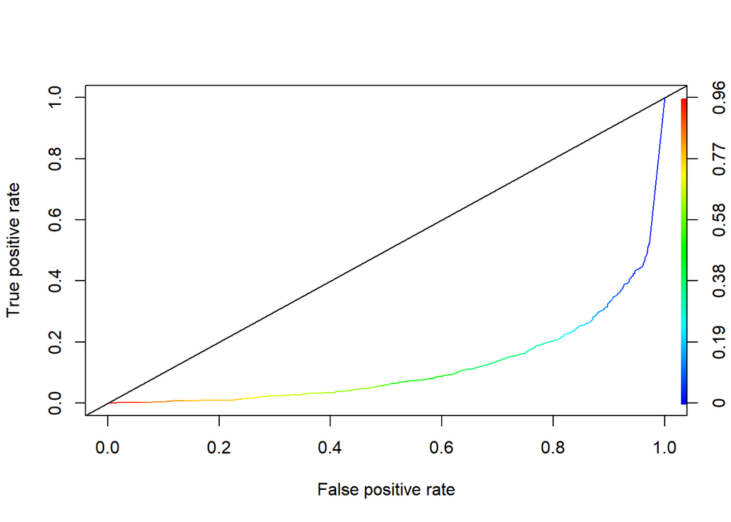

```r
#In order to use most evaluation packages it's just easier to have are predictions and targets in one place.
salary_eval <- tibble(pred_class=salary_pred_tune, pred_prob=salary_pred_tune_p$greater,target=tune$salary)

# View(salary_pred_tune$greater)
# View(tune$salary)
# View(as.numeric(tune$salary))
#View(salary_eval)

pred <- prediction(salary_eval$pred_prob,salary_eval$target)
# View(pred)

tree_perf <- performance(pred,"tpr","fpr")

plot(tree_perf, colorize=TRUE)
abline(a=0, b= 1)
```

```r
tree_perf_AUC <- performance(pred,"auc")

#print(tree_perf_AUC@y.values)
```

## Evaluation Metrics

```r
#14 Use the predict function to generate percentages, then select several
# different threshold levels using the confusion matrix function and
# interpret the results. What patterns did you notice, did the evaluation metrics change?

adjust_thres <- function(x, y, z) {
  #x=pred_probablities, y=threshold, z=test_DEATH_EVENT
  thres <- as.factor(ifelse(x > y, 1,0))
  confusionMatrix(thres, z, positive = "1", dnn=c("Prediction", "Actual"), mode = "everything")
}
levels(tune$salary) <- c("0", "1")

salary_pred_tune = predict(salary_mdl,tune, type= "prob")

#View(salary_pred_tune)
adjust_thres(salary_pred_tune$greater,.80, as.factor(tune$salary))
```

```
## Confusion Matrix and Statistics
##
##           Actual
## Prediction    0    1
##          0 3678 1017
##          1   30  159
##
##                Accuracy : 0.7856
##                  95% CI : (0.7738, 0.7971)
##     No Information Rate : 0.7592
##     P-Value [Acc > NIR] : 6.679e-06
##
##                   Kappa : 0.1782
##
##  Mcnemar's Test P-Value : < 2.2e-16
##
##             Sensitivity : 0.13520
##             Specificity : 0.99191
##          Pos Pred Value : 0.84127
##          Neg Pred Value : 0.78339
##               Precision : 0.84127
##                  Recall : 0.13520
##                      F1 : 0.23297
##              Prevalence : 0.24079
##          Detection Rate : 0.03256
##    Detection Prevalence : 0.03870
##       Balanced Accuracy : 0.56356
##
##        'Positive' Class : 1
##
```

## Adjusting Hyper-paramters

```r
#15 Based on your understanding of the model and data adjust several of the hyper-parameters via the built in train control function in caret or build and try new features, does the model quality improve? If so how and why, if not, why not?


features <- train[,-c("salary")]#dropping 12 and 13. 12 essentially predicts 13
#perfectly and 13 is our target variable
#View(features)
levels(train$salary) <- c("lower", "greater")

target <- train$salary

str(features)
```

```
## Classes 'data.table' and 'data.frame':   22793 obs. of  102 variables:
##  $ workclass_?                              : int  0 0 0 0 0 0 0 0 0 0 ...
##  $ workclass_Federal-gov                    : int  0 0 0 0 0 0 0 0 0 0 ...
##  $ workclass_Local-gov                      : int  0 0 0 0 0 0 0 0 0 0 ...
##  $ workclass_Never-worked                   : int  0 0 0 0 0 0 0 0 0 0 ...
##  $ workclass_Private                        : int  1 1 1 1 1 1 0 1 1 1 ...
##  $ workclass_Self-emp-inc                   : int  0 0 0 0 0 0 0 0 0 0 ...
##  $ workclass_Self-emp-not-inc               : int  0 0 0 0 0 0 0 0 0 0 ...
##  $ workclass_State-gov                      : int  0 0 0 0 0 0 1 0 0 0 ...
##  $ workclass_Without-pay                    : int  0 0 0 0 0 0 0 0 0 0 ...
##  $ education_10th                           : int  0 0 0 0 0 0 0 0 0 0 ...
##  $ education_11th                           : int  1 0 0 0 0 0 0 0 0 0 ...
##  $ education_12th                           : int  0 0 0 0 0 0 0 0 0 0 ...
##  $ education_1st-4th                        : int  0 0 0 0 0 0 0 0 0 0 ...
##  $ education_5th-6th                        : int  0 0 0 0 0 0 0 0 0 0 ...
```

[output cut: 87 more lines]

```r
str(target)
```

```
##  Factor w/ 2 levels "lower","greater": 1 1 1 2 2 2 2 1 2 1 ...
```

```r
#Cross validation process

fitControl <- trainControl(method = "repeatedcv",
                          number = 10,
                          repeats = 1,
                          returnResamp="all",
                          classProbs = TRUE,
                          allowParallel = TRUE)


set.seed(1984)
salary_mdl <- train(x=features,
                y=target,
                method="C5.0",
                trControl=fitControl,
                verbose=TRUE)

salary_mdl #provides us the hyper-parameters that were selected through the grid
```

```
## C5.0
##
## 22793 samples
##   102 predictor
##     2 classes: 'lower', 'greater'
##
## No pre-processing
## Resampling: Cross-Validated (10 fold, repeated 1 times)
## Summary of sample sizes: 20514, 20515, 20514, 20513, 20513, 20514, ...
## Resampling results across tuning parameters:
##
##   model  winnow  trials  Accuracy   Kappa
##   rules  FALSE    1      0.8246817  0.4787813
##   rules  FALSE   10      0.8276219  0.4666812
##   rules  FALSE   20      0.8284119  0.4708705
##   rules   TRUE    1      0.8243748  0.4767406
##   rules   TRUE   10      0.8260419  0.4575621
##   rules   TRUE   20      0.8279725  0.4717584
##   tree   FALSE    1      0.8263928  0.4880597
##   tree   FALSE   10      0.8314825  0.4962241
##   tree   FALSE   20      0.8295512  0.4985535
##   tree    TRUE    1      0.8262175  0.4857426
##   tree    TRUE   10      0.8286744  0.4832207
##   tree    TRUE   20      0.8272707  0.4820207
##
## Accuracy was used to select the optimal model using the largest value.
## The final values used for the model were trials = 10, model = tree and winnow
##  = FALSE.
```

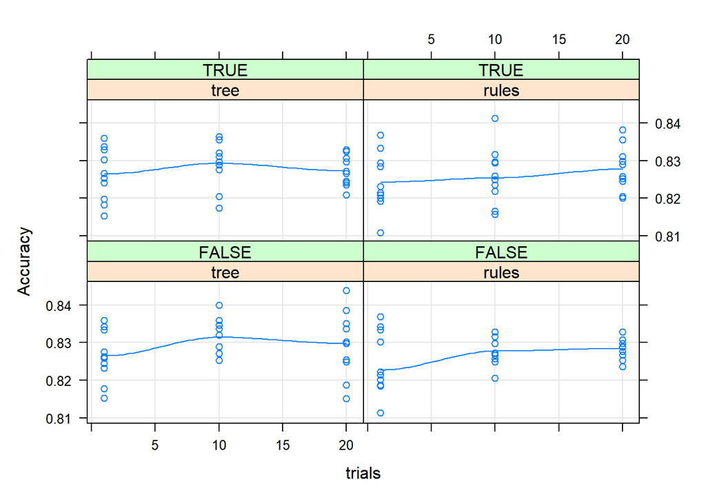

```r
xyplot(salary_mdl,type = c("g", "p", "smooth"))
```

```r
varImp(salary_mdl)
```

```
## C5.0 variable importance
##
##   only 20 most important variables shown (out of 102)
##
##                                   Overall
## education_Doctorate                100.00
## relationship_Own-child             100.00
## marital-status_Married-civ-spouse  100.00
## education_Prof-school               99.97
## relationship_Other-relative         85.04
## occupation_Priv-house-serv          84.78
## occupation_Other-service            84.59
## native-country_Vietnam              84.38
## native-country_Dominican-Republic   84.34
## education_1st-4th                   82.49
## marital-status_Never-married        81.88
## relationship_Unmarried              81.74
## education_Masters                   81.68
## native-country_Columbia             81.41
## marital-status_Married-AF-spouse    81.41
## education_10th                      73.27
## occupation_Machine-op-inspct        72.66
## education_7th-8th                   71.75
## education_11th                      71.72
## native-country_Mexico               71.30
```

```r
salary_pred_tune = predict(salary_mdl,tune, type= "raw")

levels(tune$salary) <- c("lower", "greater")
#View(tune$salary)


#Lets use the confusion matrix

(salary_eval <- confusionMatrix(as.factor(salary_pred_tune),
                as.factor(tune$salary),
                dnn=c("Prediction", "Actual"),
                mode = "sens_spec"))
```

```
## Confusion Matrix and Statistics
##
##           Actual
## Prediction lower greater
##    lower    3461     556
##    greater   247     620
##
##                Accuracy : 0.8356
##                  95% CI : (0.8249, 0.8459)
##     No Information Rate : 0.7592
##     P-Value [Acc > NIR] : < 2.2e-16
##
##                   Kappa : 0.506
##
##  Mcnemar's Test P-Value : < 2.2e-16
##
##             Sensitivity : 0.9334
##             Specificity : 0.5272
##          Pos Pred Value : 0.8616
##          Neg Pred Value : 0.7151
##              Prevalence : 0.7592
##          Detection Rate : 0.7086
##    Detection Prevalence : 0.8225
##       Balanced Accuracy : 0.7303
##
##        'Positive' Class : lower
##
```

```r
# table(tune$salary)
#
# salary_pred_tune_p = predict(salary_mdl,tune,type= "prob")
#
#
# View(salary_pred_tune_p)
```

## Performance

```r
#16 Once you are confident that your model is not improving, via changes
# implemented on the training set and evaluated on the the validation set (item 16), predict with the test set and report a final evaluation of the model. Discuss the output in comparison with the previous evaluations.


salary_pred_test = predict(salary_mdl,test, type= "raw")

levels(test$salary) <- c("lower", "greater")

#Lets use the confusion matrix

(salary_eval <- confusionMatrix(as.factor(salary_pred_test),
                as.factor(test$salary),
                dnn=c("Prediction", "Actual"),
                mode = "sens_spec"))
```

```
## Confusion Matrix and Statistics
##
##           Actual
## Prediction lower greater
##    lower    3452     599
##    greater   255     577
##
##                Accuracy : 0.8251
##                  95% CI : (0.8142, 0.8357)
##     No Information Rate : 0.7592
##     P-Value [Acc > NIR] : < 2.2e-16
##
##                   Kappa : 0.4687
##
##  Mcnemar's Test P-Value : < 2.2e-16
##
##             Sensitivity : 0.9312
##             Specificity : 0.4906
##          Pos Pred Value : 0.8521
##          Neg Pred Value : 0.6935
##              Prevalence : 0.7592
##          Detection Rate : 0.7069
##    Detection Prevalence : 0.8296
##       Balanced Accuracy : 0.7109
##
##        'Positive' Class : lower
##
```

## Summary

I learned how to apply my skills from previous assignments into this project. For instance, I gained a better understanding of how I can plot ROC/AUC curve for this classification project I also developed a stronger grasp of why separating phases of a machine learning project into training, tuning, and testing is important to develop an effective model. This model can be improved through better feature-engineering and more thoughtful selection of features. We could also do more exploratory analysis to help with this. This model can be used to help those who might be in need of financial assistance based on various factors. We can use this model to predict who might be low-income versus who might not in order to take action earlier.

```r
#17 Summarize what you learned along the way and make recommendations on how this could be used moving forward, being careful not to over promise.
```

## Reflection

The most interesting and hardest part of this process was creating a visualization of the decision tree. Understanding each step of this process was difficult and required a lot of research into each library function involved. A question I still have is how machine learning practitioners deploy their models. Currently these live on notebooks which seem cumbersome to use. How can a model such as this be hosted independently and used like an API?

```r
#18 What was the most interesting or hardest part of this process and what questions do you still have?
```